# MTH6139 Time Series

Coursework 1_ 230289143

Shilajan Surendran

Spring term 2026

# Section 1:Prophet

## Loading and plotting

I loaded the libraries prophet and zoo for the time series forecasting and for the dates that go with the time series.I then plotted the original co2 data to see the trend.

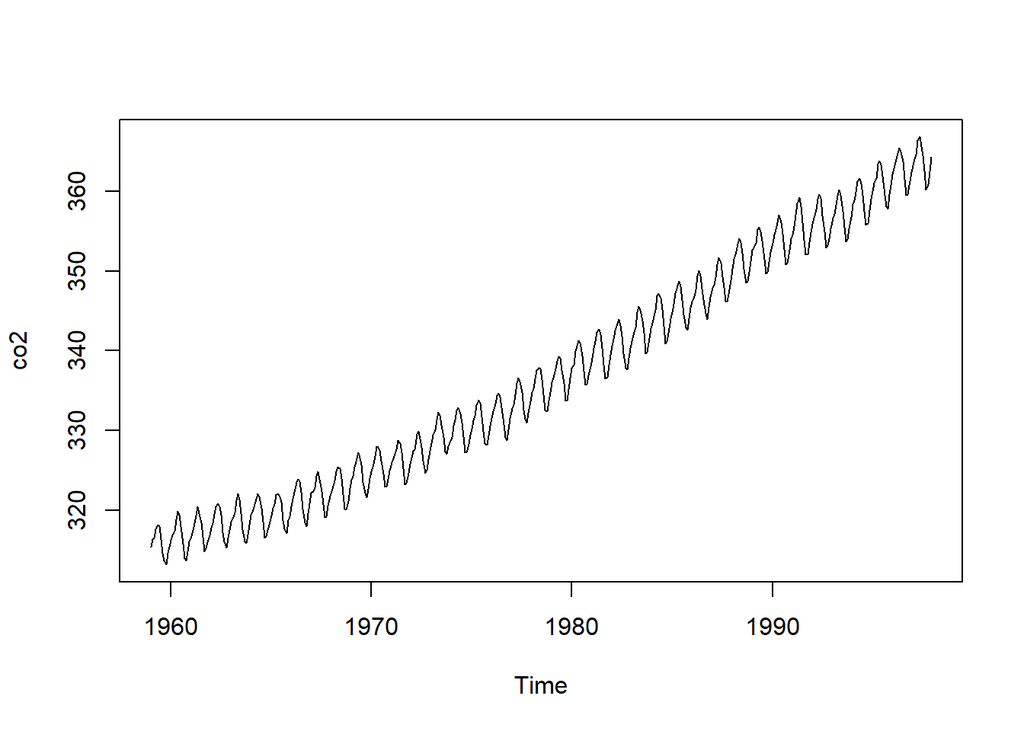

```r
library(prophet)
library(zoo)
plot(co2)
```

###Trend From the plot of the co2 data time series, there is an obvious steady increase in c02 levels over time. It also shows the fluctuations that occur in each year.

###using linear regression

```r
linreg=lm(co2~time(co2))
cf=coef(linreg); cf[2]
```

```
## time(co2)
##  1.307497
```

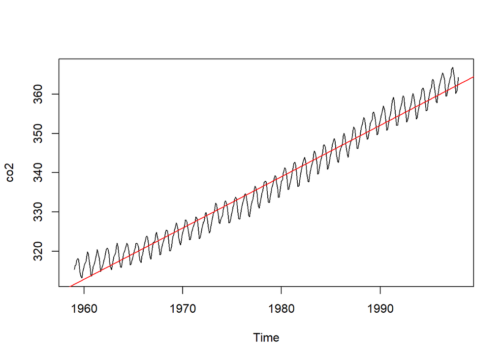

```
## integer(0)
```

```r
plot(co2)+abline(a=cf[1],b=cf[2],col='red')
```

I have applied a linear regression model to better understand the trend of the data. There is a straight line going through the data points which is showing an upwards trend, which tells me that the future data forecast will also increase.

```r
library(prophet)
start(co2)
```

```
## [1] 1959    1
```

```r
end(co2)
```

```
## [1] 1997   12
```

```r
frequency(co2)
```

```
## [1] 12
```

```r
#converting the time series data into a dataframe for Prophet
df=data.frame(
  ds = as.Date(as.yearmon(time(co2))),
  #extracting the co2 values as numbers for prophet
  y = as.numeric(co2))
#create and fitting the prophet model
model= prophet(df)
```

```
## Disabling weekly seasonality. Run prophet with weekly.seasonality=TRUE to override this.
```

```
## Disabling daily seasonality. Run prophet with daily.seasonality=TRUE to override this.
```

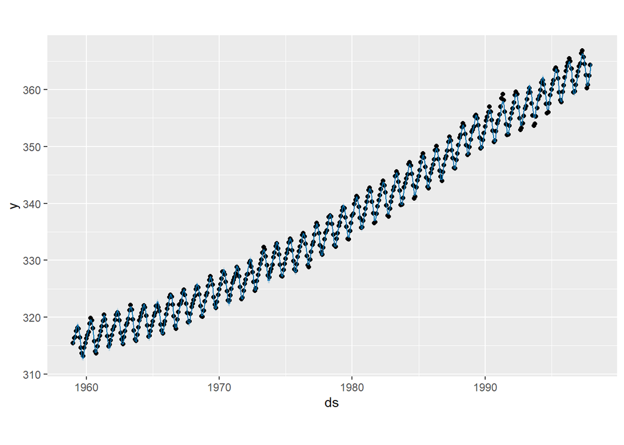

```r
#forecasting for 24 months
future = make_future_dataframe(model, periods = 24)
forecast= predict(model, future)

plot(model, forecast)
```

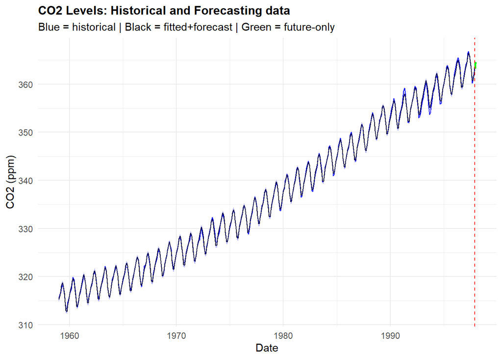

```r
library(ggplot2)

# Ensuring the date format
df$ds <- as.Date(df$ds)
forecast$ds <- as.Date(forecast$ds)

# Future-only forecast data
future_only <- forecast[forecast$ds > max(df$ds), ]

# Plotting the data
ggplot() +
  # Historical CO2 data
  geom_line(data = df, aes(x = ds, y = y), color = "blue") +

  # Full forecast (fitted + predicted)
  geom_line(data = forecast, aes(x = ds, y = yhat), color = "black") +

  # Confidence intervals
  geom_ribbon(data = forecast,
              aes(x = ds, ymin = yhat_lower, ymax = yhat_upper),
              alpha = 0.3, fill = "blue") +

  # Future-only forecast highlighted
  geom_line(data = future_only, aes(x = ds, y = yhat),
            color = "green", size = 1) +

  # line to split hist and future data
  geom_vline(xintercept = max(df$ds),
             linetype = "dashed", color = "red") +

  # Labels for the lines
  labs(title = "CO2 Levels: Historical and Forecasting data",
       subtitle = "Blue = historical | Black = fitted+forecast | Green = future-only",
       x = "Date",
       y = "CO2 (ppm)") +

  theme_minimal() +
  theme(plot.title = element_text(face = "bold", size = 12))
```

This is the graph I get after plotting the historical and the future data for the co2 time series with prophet. As you can see it shows that there is an upward trend of co2 levels as time goes by.I am unble to increase the number of future data Prophet can predict, ive tried changing the code from future = make_future_dataframe(model, periods = 24) to future = make_future_dataframe(model, periods = 120). But the graph doesn’t seem a accommodate that.I can also see a seasonal pattern from the data as there is a fluctuation of data going up and down per period. the co2 levels drop in the summer as there is an increase in plants and there is a higher amount in winter as there is less plants which are absorbing the co2.